# Foster Children and Adoptees in New York City

Vera Sticker

December 8, 2018

## The Data

This project analyzes [Foster Care File 2015](https://www.ndacan.acf.hhs.gov/datasets/dataset-details.cfm?ID=200) from the Adoption and Foster Care Analysis and Reporting System (AFCARS), a federally-mandated data collection system which states use to report adoptions and foster care placements. This dataset was tidied and uploaded by [Data4Democracy on Data.World](https://data.world/data4democracy/foster-care-nyc).

In this analysis, I want to explore this data to glean a better understanding of foster placements and adoptions in New York. Specifically, I am curious as to whether certain factors lead to more successful adoptions vs. foster care placements.

To prepare the data for analysis, I rename several columns for intelligibility and internal consistency and factorized several variables. This leads to the following information:

```
## 'data.frame':    2377 obs. of  19 variables:
##  $ RecNum        : num  2.41e+11 2.42e+11 2.41e+11 2.41e+11 2.42e+11 ...
##  $ Sex           : Factor w/ 2 levels "1","2": 1 1 1 2 1 1 1 2 1 2 ...
##  $ ClinDis       : Factor w/ 2 levels "1","2": 2 1 1 1 1 2 1 2 1 1 ...
##  $ AgeAtEnd      : int  20 20 19 19 20 19 18 18 18 18 ...
##  $ CRaceEthn     : Factor w/ 7 levels "1","2","3","4",..: 1 2 1 1 2 2 2 1 1 2 ...
##  $ PrinAgeAtBirth: int  NA 31 NA NA 26 NA 23 21 32 24 ...
##  $ PrinFamStr    : Factor w/ 5 levels "1","2","3","4",..: NA 3 NA NA 3 NA 1 1 3 3 ...
##  $ TotalRem      : int  1 1 1 1 2 1 3 1 1 2 ...
##  $ PlacesNumber  : int  7 2 3 1 6 8 3 2 10 9 ...
##  $ MannerOfRem   : Factor w/ 3 levels "1","2","3": 2 2 2 2 2 1 2 2 2 2 ...
##  $ RemRsnChil    : Factor w/ 2 levels "0","1": 1 1 1 1 1 1 2 1 1 1 ...
##  $ IsPR          : Factor w/ 2 levels "0","1": 2 2 2 1 2 2 2 2 2 2 ...
##  $ Adopted       : Factor w/ 2 levels "0","1": 2 2 2 2 2 2 2 2 2 2 ...
##  $ F1Age         : int  62 57 65 27 49 42 54 56 52 39 ...
##  $ F2Age         : int  58 NA NA 30 NA NA 51 NA NA NA ...
##  $ FosFamStr     : Factor w/ 4 levels "1","2","3","4": 2 3 NA 1 NA NA 1 1 3 2 ...
##  $ F1RaceEthn    : Factor w/ 5 levels "1","2","3","4",..: 1 2 1 1 2 2 1 1 1 2 ...
##  $ F2RaceEthn    : Factor w/ 4 levels "1","2","4","7": 1 NA NA 1 NA NA 4 NA NA NA ...
##  $ Transracial   : Factor w/ 5 levels "0","1","2","3",..: 1 1 1 1 1 1 2 1 1 1 ...
```

“Fosters” contains 19 variables and 2377 observations.

```
##      RecNum          Sex      ClinDis        AgeAtEnd     CRaceEthn
##  Min.   :1.015e+10   1:1229   1   :1678   Min.   : 8.00   1 : 666
##  1st Qu.:2.511e+11   2:1148   2   : 689   1st Qu.:11.00   2 :1147
##  Median :2.519e+11            NA's:  10   Median :13.00   3 :   5
##  Mean   :2.525e+11                        Mean   :12.89   4 :  15
##  3rd Qu.:2.604e+11                        3rd Qu.:15.00   6 :  11
##  Max.   :2.627e+11                        Max.   :20.00   7 : 326
##                                                           99: 207
##  PrinAgeAtBirth  PrinFamStr    TotalRem      PlacesNumber    MannerOfRem
##  Min.   : 8.00   1   :423   Min.   :1.000   Min.   : 1.000   1   : 124
##  1st Qu.:21.00   2   :613   1st Qu.:1.000   1st Qu.: 2.000   2   :2145
##  Median :25.00   3   :787   Median :1.000   Median : 3.000   3   :   2
##  Mean   :27.17   4   :110   Mean   :1.387   Mean   : 4.222   NA's: 106
##  3rd Qu.:32.00   5   : 85   3rd Qu.:2.000   3rd Qu.: 5.000
##  Max.   :68.00   NA's:359   Max.   :6.000   Max.   :23.000
##  NA's   :444
##  RemRsnChil  IsPR     Adopted      F1Age           F2Age       FosFamStr
##  0   :2124   0: 687   0:1811   Min.   :18.00   Min.   :23.00   1   : 493
##  1   : 147   1:1690   1: 566   1st Qu.:44.00   1st Qu.:45.00   2   :  62
##  NA's: 106                     Median :51.00   Median :51.00   3   : 599
##                                Mean   :51.22   Mean   :51.33   4   :  42
##                                3rd Qu.:58.00   3rd Qu.:59.00   NA's:1181
##                                Max.   :86.00   Max.   :84.00
##                                NA's   :616     NA's   :1693
##  F1RaceEthn F2RaceEthn  Transracial
##  1   :443   1   : 312   0   :1173
##  2   :933   2   : 235   1   :  58
##  3   :  5   4   :   8   2   :  52
##  4   : 10   7   : 129   3   :  60
##  7   :370   NA's:1693   9   : 207
##  NA's:616               NA's: 827
##
```

I will further explain the variable names as they are explored below.

# Univariate Plots Section

I want to begin with the “fosters” data, since this is the child pool from which adoptions are typically chosen. I want to know more about the characteristics of foster children as a whole. The first relevant piece of information that comes to mind is age.

### Age

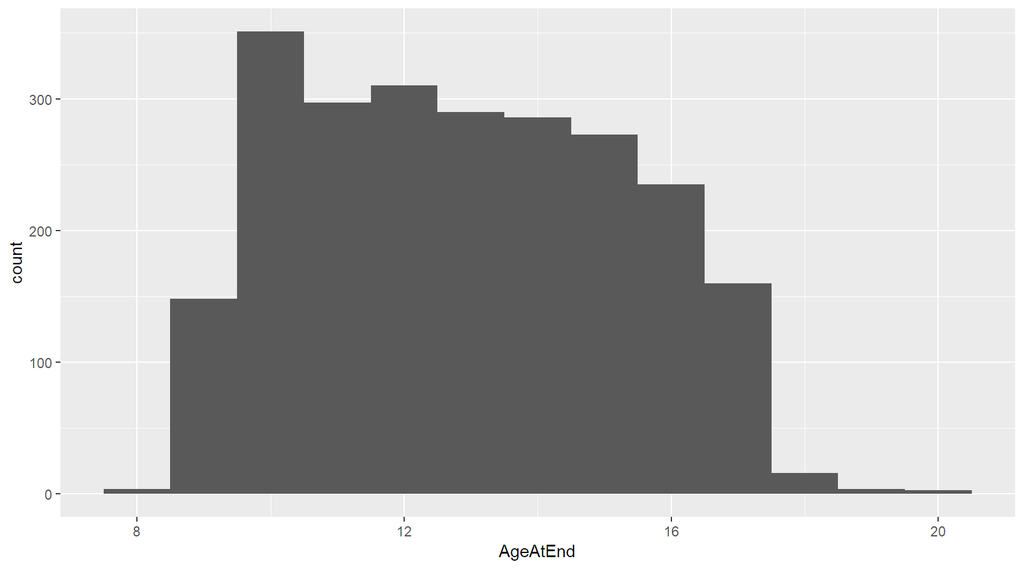

“AgeAtEnd” contains a foster child’s age either at their time of adoption (if adopted) or at the end of the fiscal year (if not). This histogram shows all foster children, both adopted and not. It seems to have a normal-ish distribution around age 13, but is slightly skewed towards the younger side.

Next, I want to look at categorical variables such as sex, disability status, and race of child.

### Sex

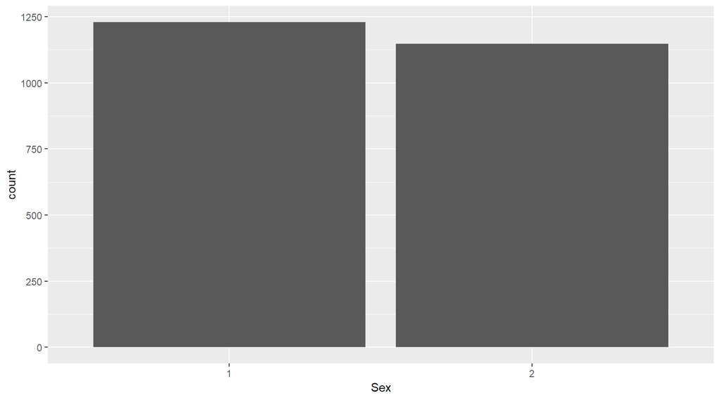

Sex is a factor with two levels: 1 for male and 2 for female. There appear to be slightly more males in the fosters data.

### Disability

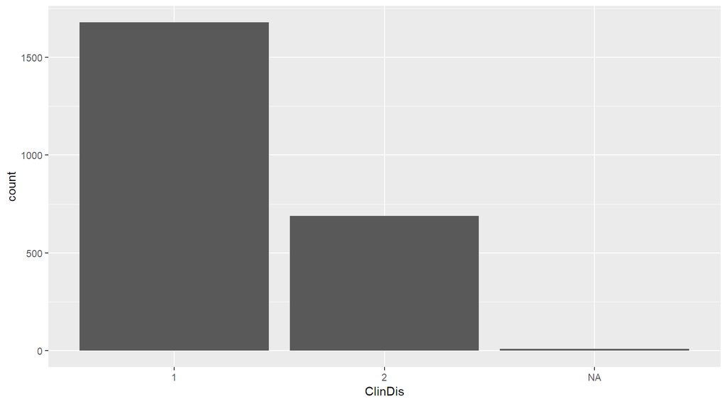

“ClinDis,” standing for Clinical Disability, is a factor with two levels: 1 for a child with a diagnosed disability, 2 for no diagnosis. An NA here means disability status is unknown. Surprisingly, there are over twice as many foster children with disabilities as without (a ratio of 2.44 to 1, specifically).

### Race/Ethnicity

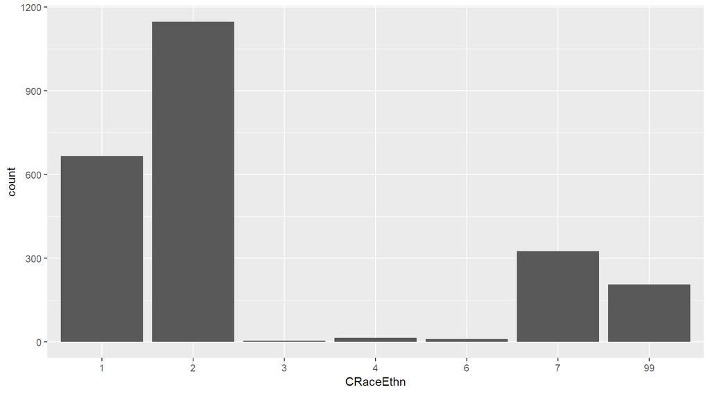

“CRaceEthn” is a factor with seven levels, each number corresponding to a race/ethnicity: 1 - White, 2 - Black, 3 - American Indian, 4 - Asian, 5 - Hawaiian/Pacific Islander, 6 - More than One Race, 7 - Hispanic, 99 - Unknown. The majority of foster children are black, then white, then Hispanic.

### Transracial Placements

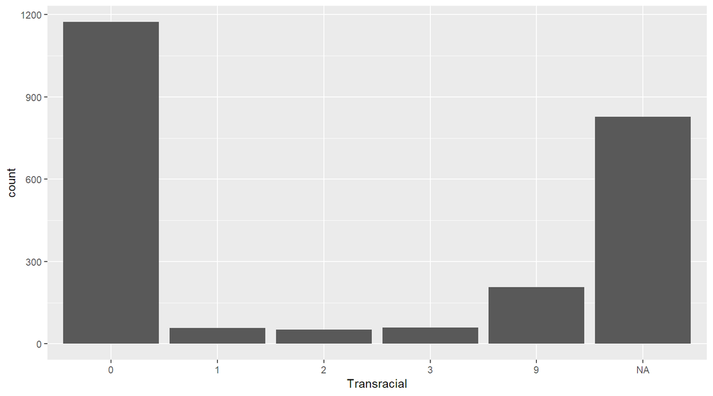

I also want to see if the child’s race differs from the foster family’s race. “Transracial” is a factor with five levels, each number corresponding to a status: 0 - not transracial, 1 - white parent/non-white child, 2 - non-white parent/white child, 3 - other transracial placement, 9 - unknown, NA - missing. Most known cases appear to be same-race placements.

There is one more set of variables I am interested in: those that relate to a child’s status in the foster system.

### Total Removals

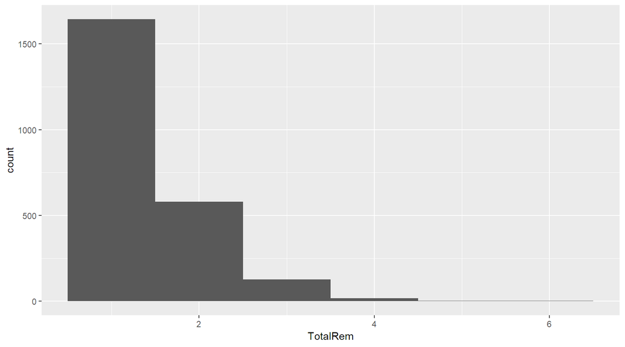

“TotalRem” refers to the number of times a child has been removed from their birth home, including the current time. The majority of children in the data appear to have been removed only once.

### Number of Placements

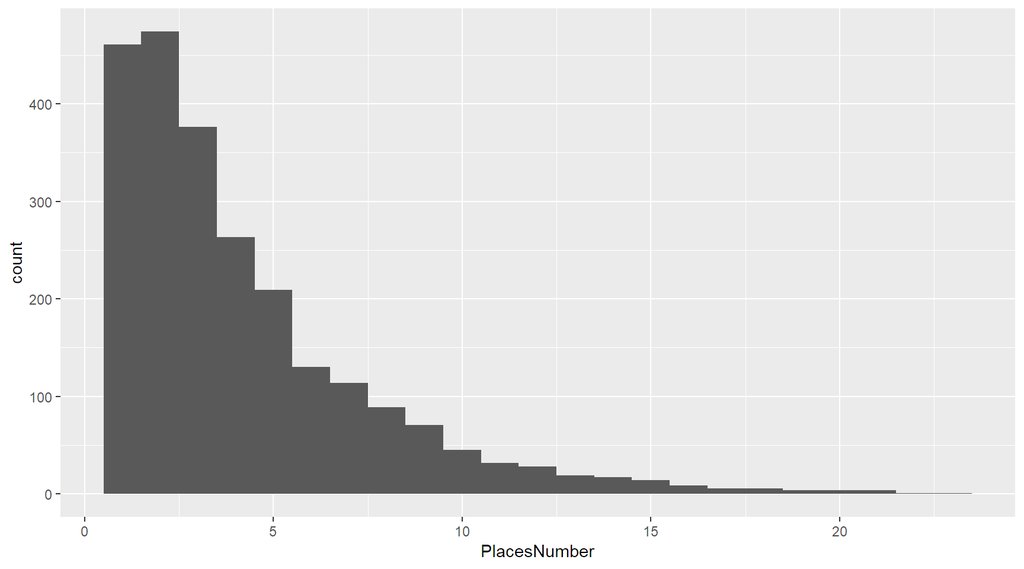

### Manner of Removal

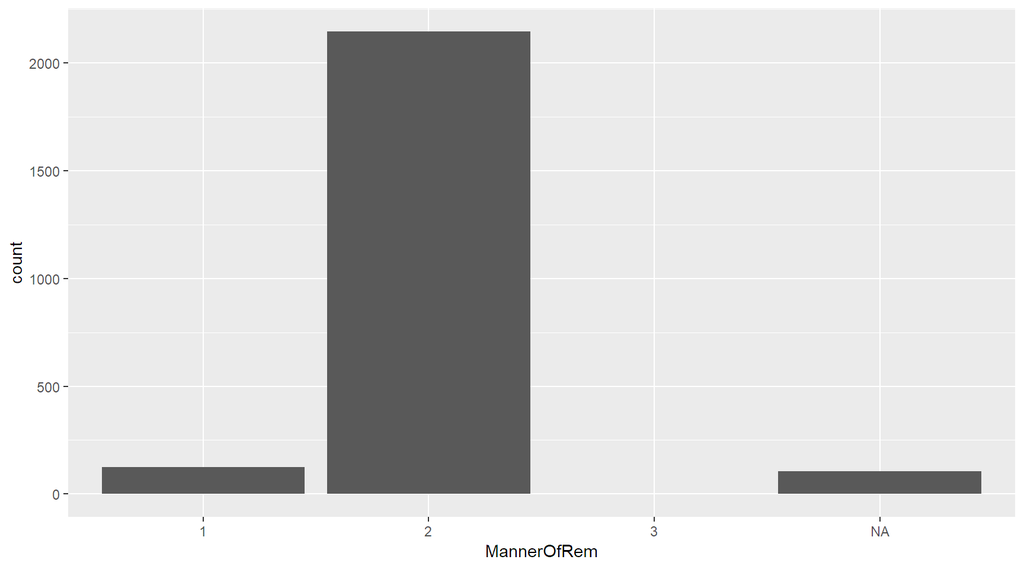

“MannerOfRem” refers to how a child ended up in the foster system: a voluntary surrender, a court order, or unknown.“NA” refers to missing values in this case. The vast majority of children were removed by court order.

### Adoptions

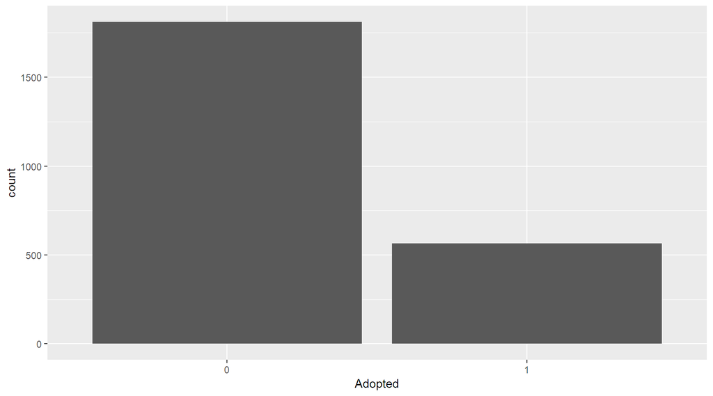

Finally, “Adopted” is a factor with two levels: 0 for not adopted, 1 for adopted. About 1/4 of the children in the dataset have been adopted. In the bivariate analysis, we can explore this, and the adoptions dataset, to see what factors may lead to this.

# Univariate Analysis

### What is the structure of your dataset?

My dataset is a dataframe containing 19 variables and 2377 observations. 12 variables are categorical (ordinal) and 6 are numeric (4 continuous, 2 discrete); the remaining variable is RecNum which contains primary key information.

### What is/are the main feature(s) of interest in your dataset?

The feature of most interest is the “adopted” variable, which indicates whether a child was adopted or not. About 1/4 of the children in the dataset were adopted. I think that most of the bivariate and multivariate analyses I run will contain this feature.

Based on the above plots, I would say that child characteristics such as age, sex, race, and disability status will be of interest.

### What other features in the dataset do you think will help support your investigation into your feature(s) of interest?

I am still interested in doing some analysis on number of removals and number of places per removal as it relates to adoptions. I am wondering if children who go through a number of removals, or a number of placements, are more or less likely to be adopted, possibly as a multivariate analysis with some of the child characteristics.

### Did you create any new variables from existing variables in the dataset?

I did not create new variables for this project. I did rename most of the existing variables for easier intelligibility and factorized the categorical variables.

# Bivariate Plots Section

### Adoption by Age

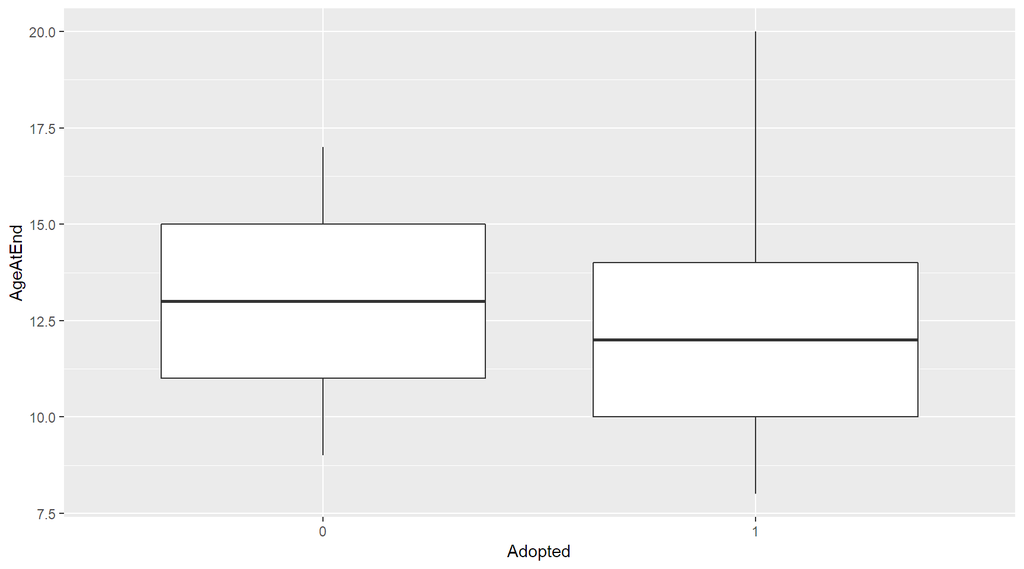

Looking at the above boxplot, we can see that the median age of adoptees appears to be slightly lower than the median age of non-adoptees. However, there do appear to be a wider range of outliers among adoptees than non-adoptees, including at least one child (or adult, in fact) who was adopted at 20 years old.

A look at the summary statistics by adoption helps clarify this data, as well as the data below:

```
## fosters$Adopted: 0
##      RecNum          Sex     ClinDis        AgeAtEnd     CRaceEthn
##  Min.   :1.015e+10   1:939   1   :1298   Min.   : 9.00   1 :492
##  1st Qu.:2.510e+11   2:872   2   : 503   1st Qu.:11.00   2 :894
##  Median :2.519e+11           NA's:  10   Median :13.00   3 :  5
##  Mean   :2.522e+11                       Mean   :13.04   4 : 12
##  3rd Qu.:2.604e+11                       3rd Qu.:15.00   6 :  8
##  Max.   :2.627e+11                       Max.   :17.00   7 :230
##                                                          99:170
##  PrinAgeAtBirth  PrinFamStr    TotalRem      PlacesNumber    MannerOfRem
##  Min.   : 8.00   1   :322   Min.   :1.000   Min.   : 1.000   1   :  99
##  1st Qu.:21.00   2   :460   1st Qu.:1.000   1st Qu.: 2.000   2   :1631
##  Median :25.00   3   :627   Median :1.000   Median : 3.000   3   :   0
##  Mean   :27.24   4   : 94   Mean   :1.411   Mean   : 4.436   NA's:  81
##  3rd Qu.:32.00   5   : 62   3rd Qu.:2.000   3rd Qu.: 6.000
##  Max.   :68.00   NA's:246   Max.   :6.000   Max.   :23.000
##  NA's   :308
##  RemRsnChil  IsPR     Adopted      F1Age           F2Age      FosFamStr
##  0   :1613   0: 678   0:1811   Min.   :18.00   Min.   :26.0   1   : 329
##  1   : 117   1:1133   1:   0   1st Qu.:44.00   1st Qu.:45.0   2   :  35
##  NA's:  81                     Median :51.00   Median :51.0   3   : 419
##                                Mean   :50.96   Mean   :51.6   4   :  28
##                                3rd Qu.:58.00   3rd Qu.:59.0   NA's:1000
##                                Max.   :86.00   Max.   :84.0
##                                NA's   :605     NA's   :1336
##  F1RaceEthn F2RaceEthn  Transracial
##  1   :264   1   : 194   0   :784
##  2   :656   2   : 188   1   : 41
##  3   :  2   4   :   4   2   : 37
##  4   :  5   7   :  89   3   : 40
##  7   :279   NA's:1336   9   :170
##  NA's:605               NA's:739
##
## --------------------------------------------------------
## fosters$Adopted: 1
##      RecNum          Sex     ClinDis    AgeAtEnd     CRaceEthn
##  Min.   :1.234e+10   1:290   1:380   Min.   : 8.00   1 :174
##  1st Qu.:2.512e+11   2:276   2:186   1st Qu.:10.00   2 :253
##  Median :2.519e+11                   Median :12.00   3 :  0
##  Mean   :2.535e+11                   Mean   :12.39   4 :  3
```

[output cut: 12 more lines]

```
##  0   :511   0:  9   0:  0   Min.   :27.00   Min.   :23.00   1   :164
##  1   : 30   1:557   1:566   1st Qu.:45.00   1st Qu.:43.00   2   : 27
##  NA's: 25                   Median :52.00   Median :50.00   3   :180
##                             Mean   :51.79   Mean   :50.72   4   : 14
##                             3rd Qu.:58.00   3rd Qu.:57.00   NA's:181
##                             Max.   :80.00   Max.   :78.00
##                             NA's   :11      NA's   :357
##  F1RaceEthn F2RaceEthn Transracial
##  1   :179   1   :118   0   :389
##  2   :277   2   : 47   1   : 17
##  3   :  3   4   :  4   2   : 15
##  4   :  5   7   : 40   3   : 20
##  7   : 91   NA's:357   9   : 37
##  NA's: 11              NA's: 88
##
```

We can see that the median age of adoptees is 12, while the median of non- adoptees is 13. The max of adoptees is indeed 20, while the max of non-adoptees is only 17. The IQR of both groups is 4, which indicates a very similar distribution overall.

I want to look more at the age distribution question, and I think I need more data. The Data4Democracy link also hosts an adoptions dataset based on the [Adoptions File 2015](https://www.ndacan.acf.hhs.gov/datasets/dataset-details.cfm?ID=201). This contains 1933 observations of 13 variables, including characteristic data like age, sex, race, and special needs status.

```
##      RecNum          Sex     SpecNeeds   AgeAtAdopt   CRaceEthn
##  Min.   :1.012e+10   1:995   1:  20    Min.   : 0.0   1 :620
##  1st Qu.:2.522e+11   2:938   2:1913    1st Qu.: 3.0   2 :795
##  Median :2.611e+11                     Median : 6.0   3 :  4
##  Mean   :2.466e+11                     Mean   : 6.7   4 : 10
##  3rd Qu.:2.618e+11                     3rd Qu.:10.0   6 :  6
##  Max.   :2.627e+11                     Max.   :20.0   7 :268
##                                                       99:230
##  BioMomAgeAtBirth BioMomMarried  AdoptMomAge     AdoptDadAge
##  Min.   :12.00    1   : 166     Min.   :24.00   Min.   :23.00
##  1st Qu.:21.00    2   :1493     1st Qu.:42.00   1st Qu.:41.00
##  Median :25.00    3   : 231     Median :49.00   Median :47.00
##  Mean   :26.22    NA's:  43     Mean   :49.35   Mean   :48.07
##  3rd Qu.:31.00                  3rd Qu.:56.00   3rd Qu.:55.00
##  Max.   :59.00                  Max.   :81.00   Max.   :80.00
##  NA's   :30                     NA's   :43      NA's   :987
##  AdoptFamStr AdoptMomRaceEthn AdoptDadRaceEthn Transracial
##  1   :877    1 :722           1 : 560          0:1251
##  2   : 69    2 :772           2 : 199          1:  97
##  3   :897    3 :  4           3 :   5          2:  94
##  4   : 47    4 :  3           4 :   4          3: 179
##  NA's: 43    5 :  6           5 :   1          9: 312
##              7 :346           7 : 162
##              99: 80           99:1002
```

I merge the two datasets into an “allCases” dataframe and melted the age information to plot a dual histogram, which gives us age distribution by adoption status.

> **Note**: To get the most accurate distinction between adoptees and non-adoptees, I plotted this histogram using only non-adoptees (“Adopted==‘0’”) from the foster care dataset.

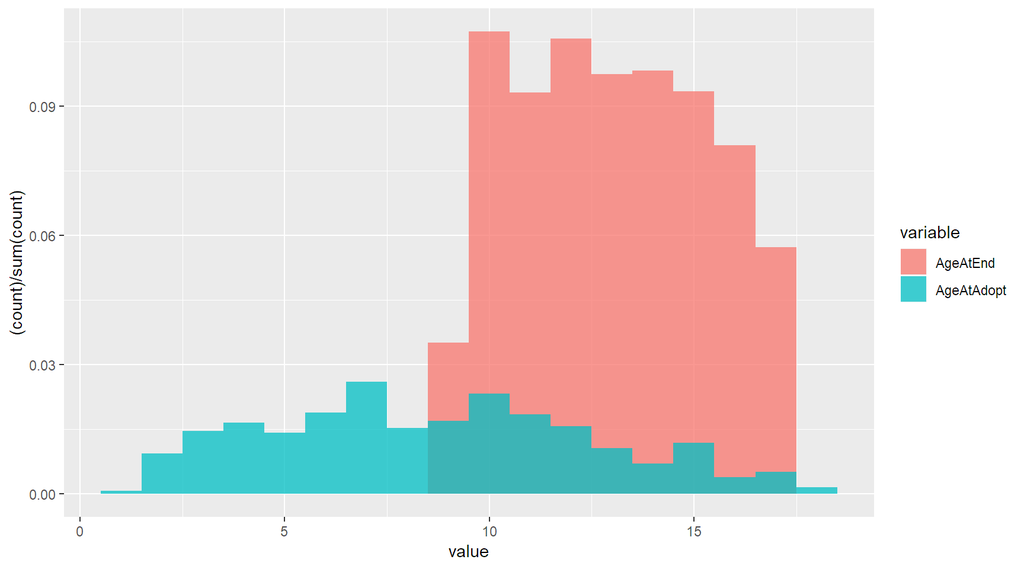

> **Note**: It is worth noting that the youngest child in the foster dataset was 8 years old, while the youngest adoptee is 0 (a newborn), so it is possible that this difference arises in part because of different samples. However, the boxplots above also showed a difference. Between the two plots, it seems possible that there is a strong relationship between age and adoption status, but we cannot say so for sure.

### Adoption by Disability Status

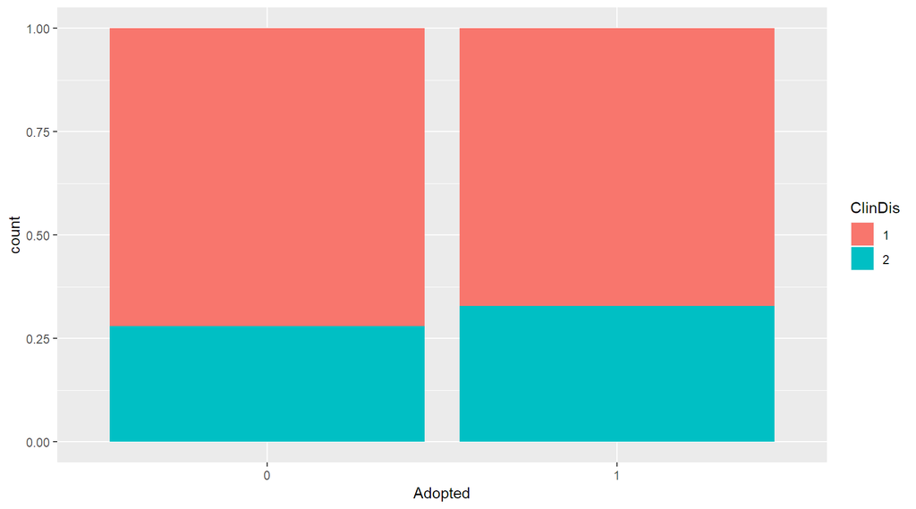

This stacked bar plot shows that children with disabilities (red) are, proportionally, adopted slightly less than children without disabilities.

This seems to track when we compare the numbers between the fosters and adoptions datasets above. While we must exercise caution in assuming that “Clinical Disability” and “Special Needs” refer to the same children, we *can* see that while there are 2.44 as many children with disabilities as without in the foster care file, there are a whopping 95.65 children without special needs to 1 child with special needs in the adoption file.

### Adoption by Sex

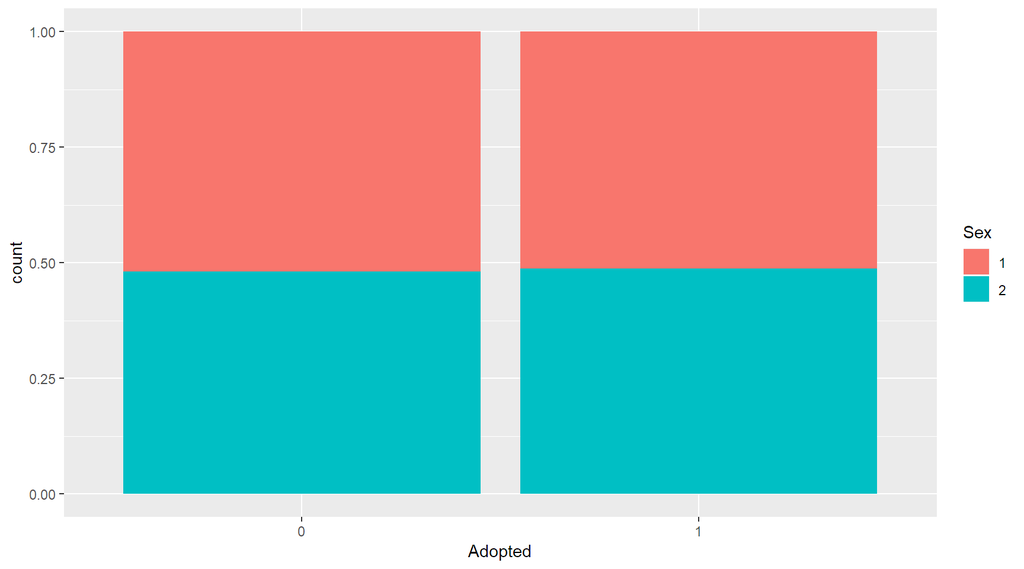

Sex, on the other hand, seems to be roughly equal, and this also tracks with the adoption information above (where the ratio of male to female is 1.06 to 1).

### Adoption by Race/Ethnicity

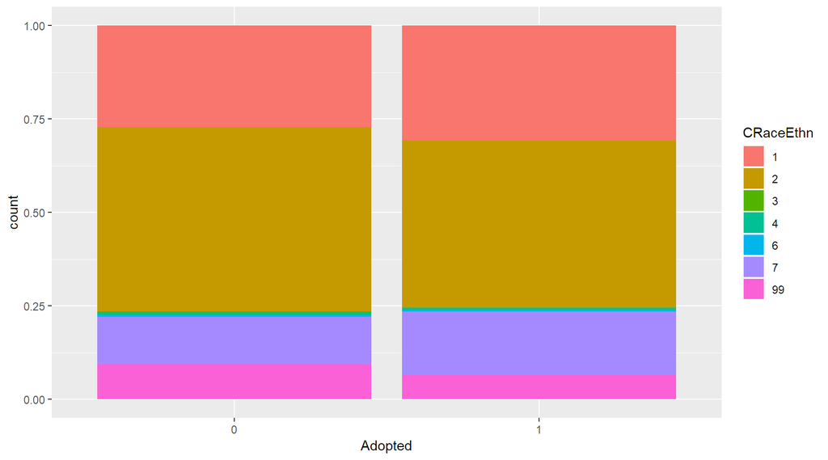

There seem to be a few small differences in adoption by race/ethnicity. White children (red bar) and Hispanic children (purple bar) seem to be adopted slightly more often, while black children (tan bar) seem to be adopted slightly less. Because this is a slightly more complex question than sex, and because both datasets share the same “CRaceEthn” variable (with the same coding), I want to see if I can get any further information by running another combined plot.

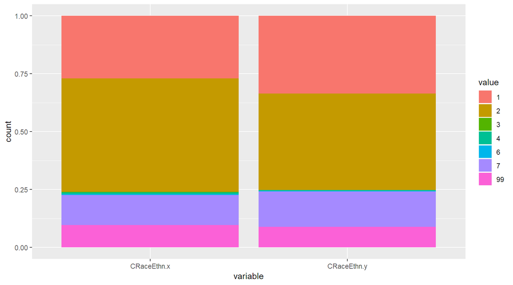

```
## [1] "Fosters (non-adoptees):"
```

```
##   1   2   3   4   6   7  99
## 492 894   5  12   8 230 170
```

```
## [1] "Adoptions:"
```

```
##   1   2   3   4   6   7  99
## 620 795   4  10   6 268 230
```

Based on the above, it seems as though our observations mostly hold true when we combine the datasets. Going by the numbers, white children represent 27% of the 1811 non-adoptees in the foster care file, but 32% of children in the adoptions file. Black children represent 49% of non-adoptees and 41% of adoptees. However, Hispanic children represent 13% of non-adoptees and 14% of adoptees, which appears to be a smaller difference than using only the foster care file made it seem.

### Adoption by Removal Status

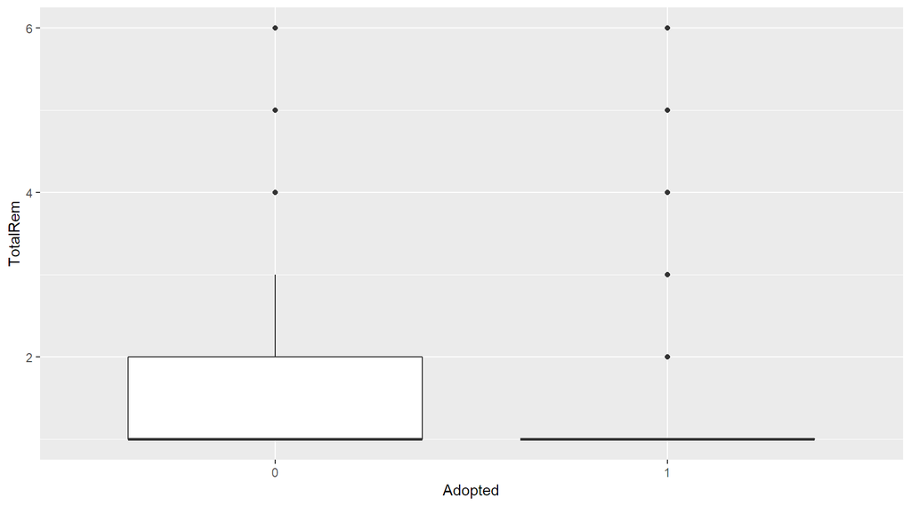

This plot shows the distribution of number of removals by adoption status. It appears that while children who have been removed up to six times are being adopted, the vast majority of adoptees are on their first removal. The majority of non-adoptees are on either their first or second removal.

### Adoption by Number of Placements

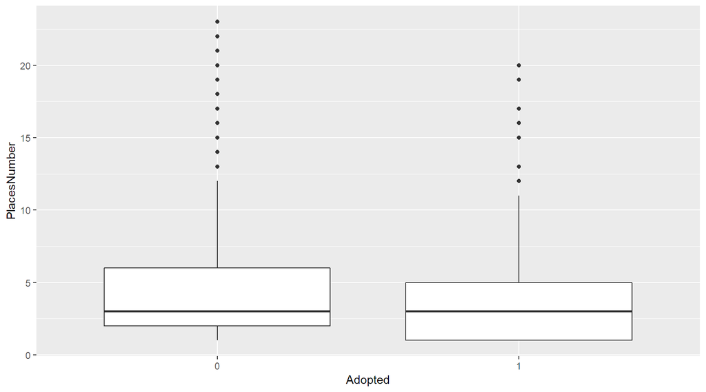

This plot yields an interesting result: while the median number of placements for adopted and non-adopted children are identical (3), adoptees appear equally distributed around this median from 1 to 5, while non-adoptees mostly fall between 2 and 6 with a longer tail in the positive direction.

Indeed, the mean of this group is 4.436 placements, while the mean of adoptees is 3.535. This indicates that while the two groups are similar around the median, some non-adoptees are experiencing much higher numbers of placements than adoptees. However, both this and the removals graph above raise a new question: if there is a connection between placements/removals and adoption, which way does that connection work? That is, are children who are at risk of multiple removals/placements less likely to be adopted, or does adoption cut down on the potential for multiple removals/placements?

### Placement Numbers by Age

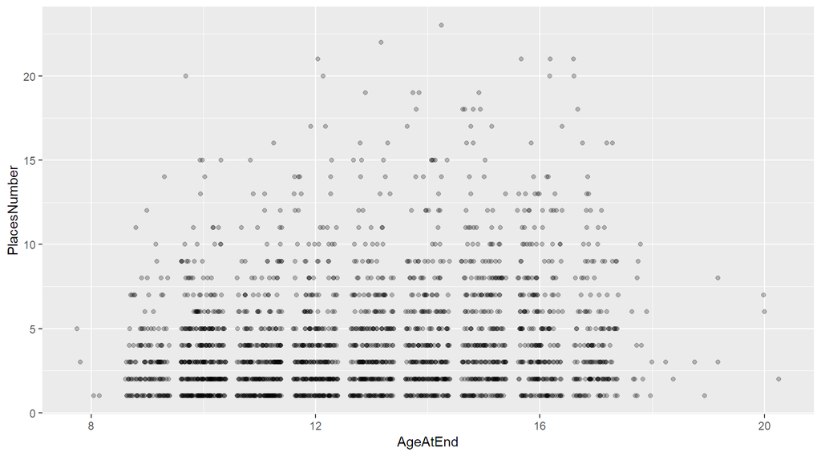

### Total Removals by Age

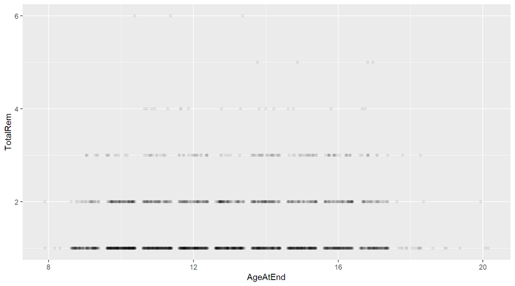

I decided to see if age (as a proxy for time) would have a clear relationship with either placements or removals, such that it could explain one or the other connection with adoption. However, neither variable appears to have a linear relationship with age. That is, foster children at all ages are seeing multiple removals or placements.

### Number of Placements by Total Removals

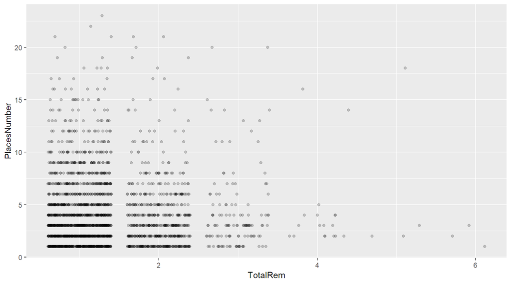

Finally, I decided to see if there is any relationship between the number of removals and number of placements. Based on this plot, there does not appear to be a clear linear relationship between the two. Children are most likely to have a low number of both removals and placements, but may also have many placements ontheir first removal. It does appear that as the number of removals grows, the number of placements does typically decrease, but it is not clear if that is a true relationship or simply a relative lack of data at the higher removal levels.

# Bivariate Analysis

### Talk about some of the relationships you observed in this part of the investigation. How did the feature(s) of interest vary with other features in the dataset?

As expected, adoption rates varied depending on certain factors. Age, disability status, and race (in some cases) appear to have some relationship to adoption rates. Sex did not appear to have a relationship with adoption rates, however. The number of removals and placements appear to be connected to adoption rates in some way, but it is difficult to tell what the nature of that connection is.

### Did you observe any interesting relationships between the other features (not the main feature(s) of interest)?

Age (as a proxy for time) did not appear to be related to either number of removals or number of placements per removal. Number of removals and placement per removal also did not appear to be related to each other.

### What was the strongest relationship you found?

The strongest relationship appears to be between age and adoption. There is a very clear difference in ages between children who are adopted and foster children who were never adopted. Again, this may be something of a two-way relationship, in which older children are less likely to be adopted, and simultaneously, non-adoptees are disadvantaged by continuing to age in the foster care system.

# Multivariate Plots Section

After exploring the bivariate relationships above, I want to take a more nuanced look at the relationships between age, removals, and placements. I am wondering if there are ways to tease out the directionality of those relationships. Is it possible that other characteristics of children or placements modify those relationships in a revealing way?

### Adoptions and Age by Total Removals

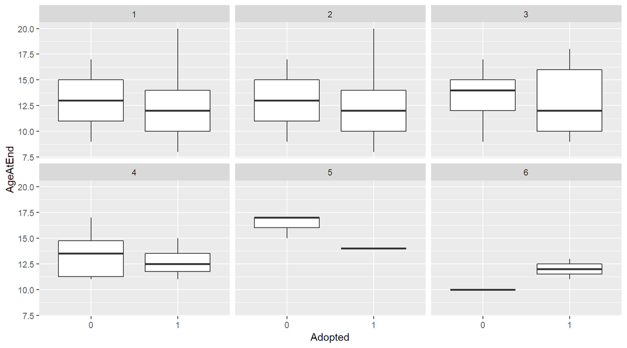

This plot shows the breakdown of adoptee/non-adoptee age at every step of total removals (e.g. each boxplot is adoption by age, from one removals to six). At all but the highest number of removals, non-adoptees have a higher median age than adoptees. However, there are no other notable patterns or relationship markers.

### Age and Number of Placements by Adoption Status

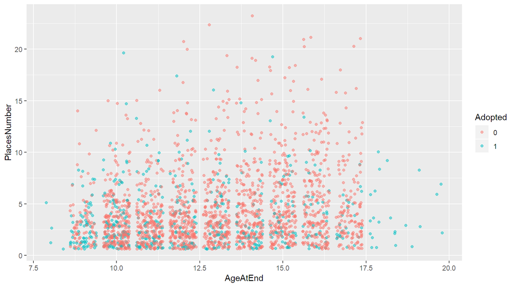

This plot remakes the Number of Placements by Age plot and factors in adoption status. There does not appear to be any additional relationship here.

### Adoptions and Age by Disability Status

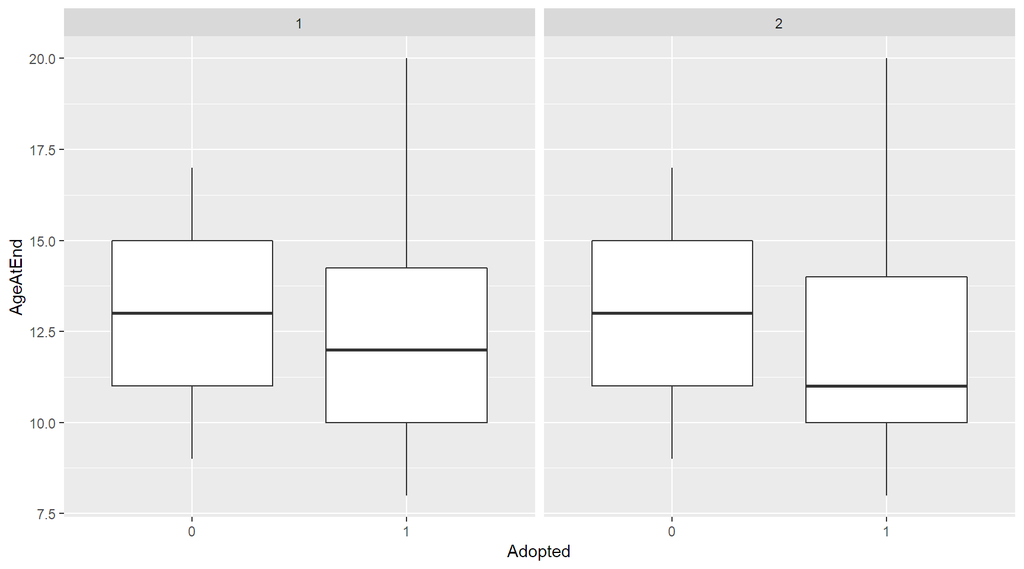

I decided next to explore other characteristics through the lens of age and our feature, adoption. One item of interest appears in this plot of age/adoption broken down by disability status: while non-adoptees have virtually identical age distributions across disability status, adoptees with disabilities have a slightly higher median age than adoptees without disabilities.

More specifically, adoptees with disabilities have a median age of just over 12, while adoptees without disabilities have a median age of around 11. Non-adoptees with and without disabilities have a median age of around 13.

### Race and Age by Adoption Status

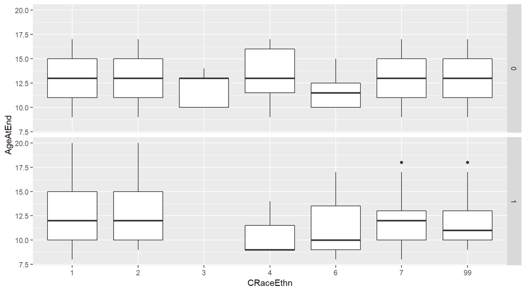

This plot shows the age distributions of the different races, broken down by adoption status. As expected, the median ages of adoptees continue to be lower than the median ages of non-adoptees. However, there are two items of interest here: first, this plot highlights the spread of adoption into the higher ages, as nearly every race band has more positive outliers among adoptees than non- adoptees. Second, that the lowering of the median age appears largely uniform between white and black children, contrary to my own expectation (that black adoptees would skew younger than white adoptees). It is also worth noting something that was very difficult to see on the previous plot, which is that amongst the fosters dataset, no American Indian children were adopted. However, there are American Indian adoptees in the adoptions dataset, as shown in the printout above.

# Multivariate Analysis

### Talk about some of the relationships you observed in this part of the investigation. Were there features that strengthened each other in terms of looking at your feature(s) of interest?

The multivariate plots relating to age tended to strengthen the idea that age and adoption status are related, and that adoptees have lower ages on the whole than non-adoptees. Additionally, looking at age and disability status across adoption revealed that adoptees with disabilities have a higher median age than adoptees without disabilities, though still lower than non-adoptees of any disability status.

# Final Plots and Summary

### Plot One

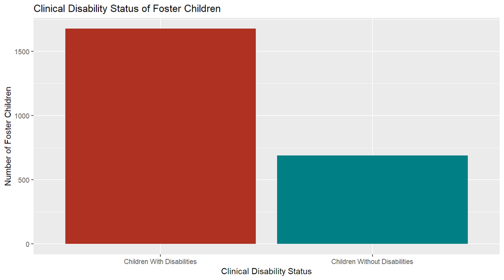

### Description One

It is important to note that “clinical disability” is an extremely broad category that can include anything from physical disabilities like paralysis and cerebral palsy, to educational disabilities like ADHD, to emotional disabilities like major depression or bipolar. Additionally, the experience of going into the foster care system in and of itself can contribute to intellectual and emotional disabilities. However, even taking that into account, I still found this information surprising and interesting.

### Plot Two

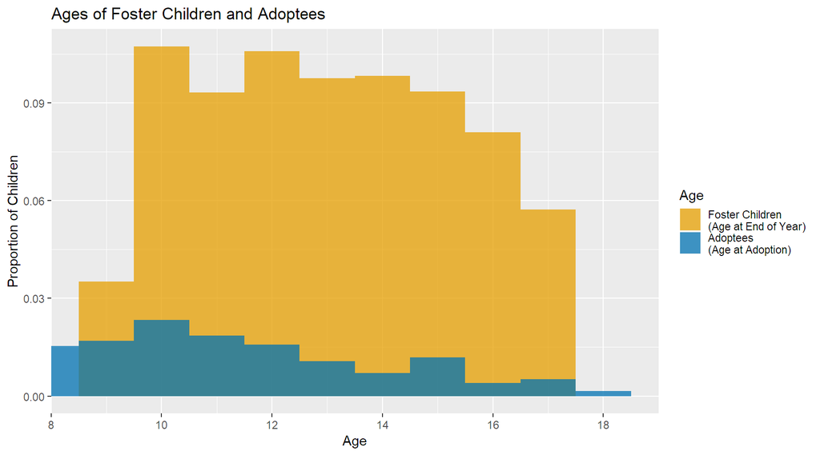

### Description Two

The above plot shows the age distribution of non-adoptees in the foster system (measured by age at the end of the fiscal year) contrasted with the age distribution of adoptees (at their age of adoption). Because the minimum age in the foster care file is 8, compared to 0 for the adoption file, I chose to focus on ages 8-18.

While the lack of younger children in the foster care file may lead to some skew in this data, there was also a clear difference in ages between adoptees and non- adoptees in the foster care file alone. I chose this plot because it is a more visually-striking way to depict the difference in ages. Clearly, younger children are favored in the adoption system.

### Plot Three

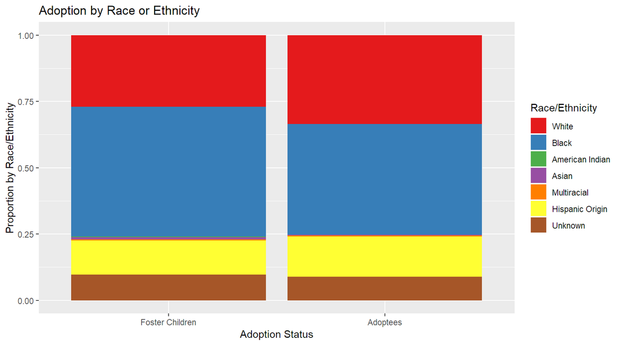

# Reflection

For this assignment, I wanted to look at the characteristics of foster children in New York in 2015 and explore for any characteristics of the children themselves, or their circumstances/experiences in the foster system, that would show which children are more likely to be adopted or not adopted. I am coming to this Nanodegree program from a background in early childhood and special education, and I want to keep working with and for children, so I chose this dataset as one that really reflects my professional and research interests.

I think that it was good that I chose a dataset that I really connected with, because it was good motivation to dig deep and really focus on the problem and the variables I thought relevant. On the other hand, I think my choice of dataset caused a few struggles, especially because most of the variables I had to work with were categorical. I could have had a wider variety of plot, and done more interesting and varied things with the plots, if I had more continuous numerical data to work with. Because I was so focused on the children themselves, I really only had age, number of removals, and number of placements to work with, and the latter two did not yield many interesting results. I also did not end up yielding much from the multivariate plots, and I think again that was partly due to the limitations of categorical variables. In the future, for an assignment like this, I might try to look for an option that would contain more continuous variables to work with.

However, that’s not to say that categorical variables are useless, or that I learned nothing from this dataset! I saw important differences in age, race, and disability status between adoptees and non-adoptees, and I can think of many future projects that could be done on any one of those variables. Because my background is in special education, I might particularly like to take a closer look at disability, and see if I can find additional data such as types of disability, or if one type of disability is more likely to lead to adoption than another.

All in all, despite some struggles and frustrations with variety or applicability of plots, I am pleased with the results of this assignment. I think I will be taking another look at this dataset, or similar datasets, as a personal project once the Nanodegree is over.